### Models for Socio-Environmental Data

#### May 25, 2018

#### Table of Contents

I. Motivation

II. Derived quantities with the logisic

III. Lizards on islands

IV. References

#### I. Motivation

JAGS allows you to implement models of high dimension once you master its syntax and logic. It is a great tool for ecological analysis. The problems that follow challenge you to:

- Write joint distributions as a basis for writing JAGS code.
- Write JAGS code to compute posterior distributions of derived quantities.
- Plot model output in revealing ways.
- Understand the effect of vague priors on parameters on predictions of non-linear models.

#### II. Derived quantities with the logisic

One of the most useful features of MCMC is its equivariance property which means that any quantity that is a function of a random variable in the MCMC algorithm becomes a random variable. Consider two quantities of interest that are functions of our estimates of the random variables $r$ and $K$:

```r
{ # Extra bracket needed only for R markdown files
sink("LogisticJAGS.R")
cat("
model{
  # priors
  K ~ dunif(0, 4000)
  r ~ dunif (0, 2)
  sigma ~ dunif(0, .5)
  tau <- 1/sigma^2

  # likelihood
  for(i in 1:n){
    mu[i] <- r - r/K * x[i]
    y[i] ~ dnorm(mu[i], tau)
  }

  # derived quantities
  # calculate maximum growth rate
  maxdNdt <- K/2
  # calculate growth rate over range of N values. N must be read in as data:
  for (j in 1:length(N)){
    dNdt[j] <- r * N[j] * (1 - N[j]/K)
  }
}
",fill = TRUE)
sink()
} # Extra bracket needed only for R markdown files
```

```r
library(ESS575)
library(rjags)
set.seed(1)

Logistic <- Logistic[order(Logistic$PopulationSize),]

inits = list(
  list(K = 1500, r = .2, sigma = .01),
  list(K = 1000, r = .15, sigma = .5),
  list(K = 900, r = .3, sigma = .01))

N <- seq(0,1500,10)
N[1] <- 1

data = list(
  n = nrow(Logistic),
  x = as.double(Logistic$PopulationSize),
  y = as.double(Logistic$GrowthRate),
  N = N)

n.adapt = 5000
n.update = 10000
n.iter = 10000

jm = jags.model("LogisticJAGS.R", data = data, inits = inits, n.chains = length(inits), n.adapt = n.adapt)
update(jm, n.iter = n.update)
zm = coda.samples(jm, variable.names = c("K", "r", "sigma", "maxdNdt"), n.iter = n.iter, n.thin = 1)
zj = jags.samples(jm, variable.names = c("r", "maxdNdt", "dNdt"), n.iter = n.iter, n.thin = 1)
```

```r
summary(zm)
```

```
##
## Iterations = 15001:25000
## Thinning interval = 1
## Number of chains = 3
## Sample size per chain = 10000
##
## 1. Empirical mean and standard deviation for each variable,
##    plus standard error of the mean:
##
##              Mean        SD  Naive SE Time-series SE
## K       1.238e+03 64.121228 3.702e-01      7.953e-01
## maxdNdt 6.191e+02 32.060614 1.851e-01      3.977e-01
## r       2.007e-01  0.009774 5.643e-05      1.181e-04
## sigma   2.868e-02  0.003041 1.756e-05      2.463e-05
##
## 2. Quantiles for each variable:
##
##              2.5%       25%       50%       75%     97.5%
## K       1.130e+03 1.194e+03 1.232e+03 1.276e+03 1.381e+03
## maxdNdt 5.649e+02 5.969e+02 6.161e+02 6.381e+02 6.905e+02
## r       1.814e-01 1.943e-01 2.008e-01 2.072e-01 2.198e-01
## sigma   2.347e-02 2.654e-02 2.842e-02 3.052e-02 3.539e-02
```

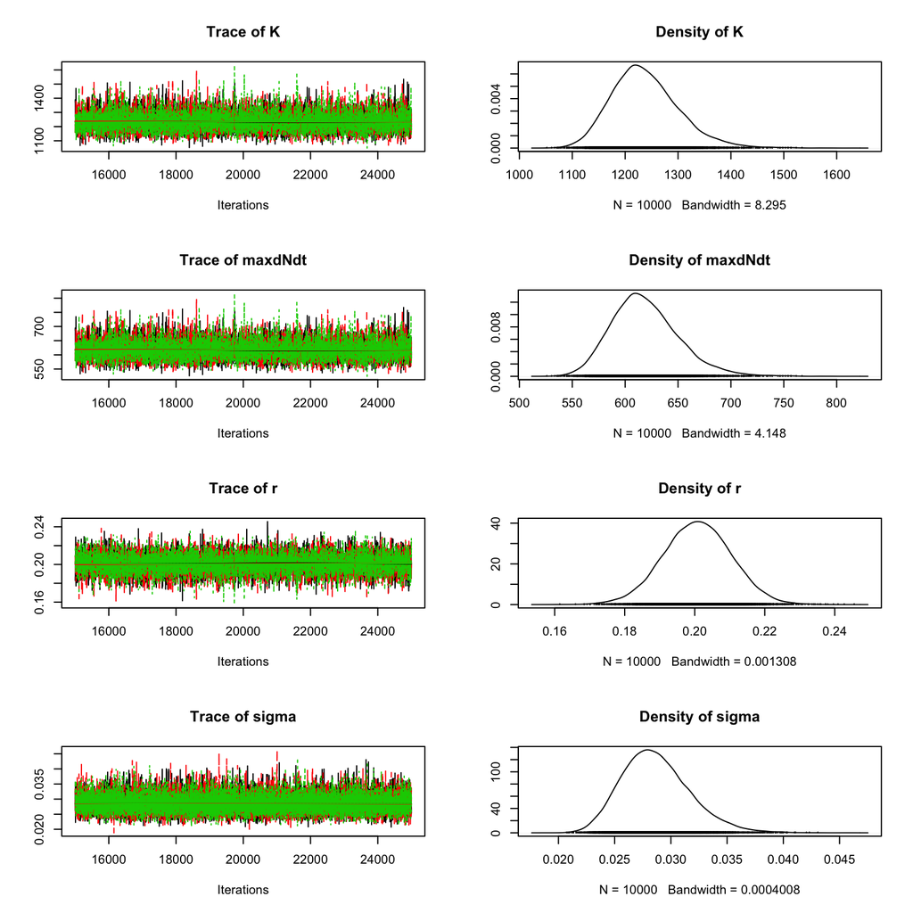

```r
plot(zm)
```

```r
gelman.diag(zm, multivariate = FALSE)
```

```
## Potential scale reduction factors:
##
##         Point est. Upper C.I.
## K                1          1
## maxdNdt          1          1
## r                1          1
## sigma            1          1
```

2. Plot the median population growth rate rate and 95% credible intervals as a function of $N$. What does this curve tell you about the difficulty of sustaining harvest of populations?

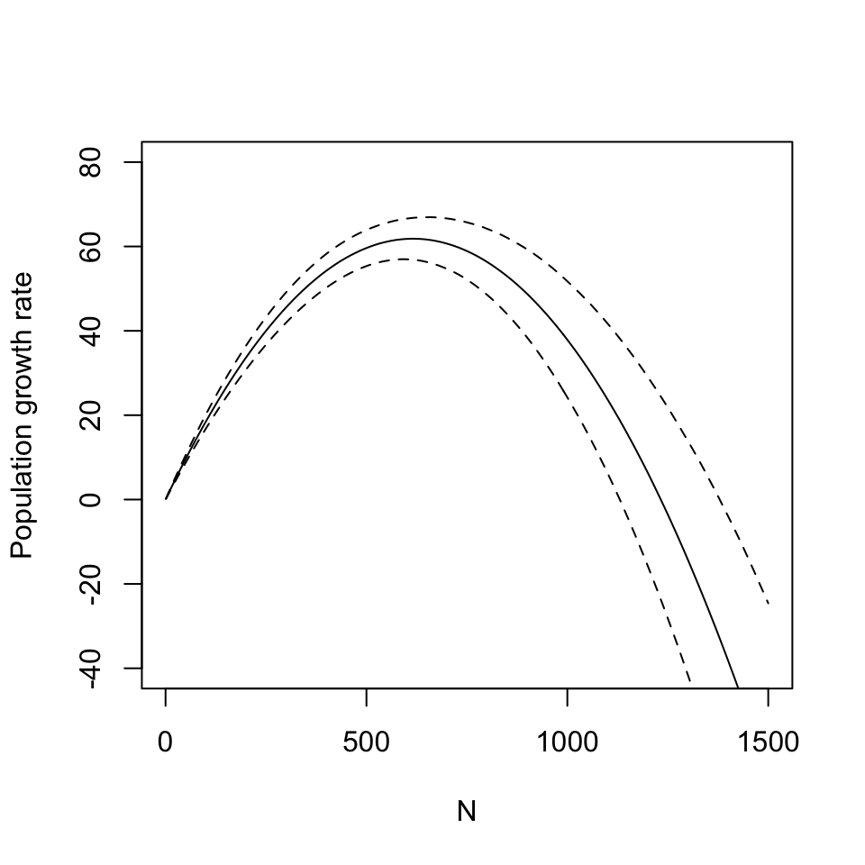

```r
b <- summary(zj$dNdt, quantile, c(.025, .5, .975))$stat
plot(N, b[2,], xlab = "N", ylab = "Population growth rate", type = "l", ylim = c(-40, 80))
lines(N, b[1,], lty = "dashed")
lines(N, b[3,], lty = "dashed")
```

3. What is the probability that the intrinsic rate of increase $(r)$ exceeds .22? What is the probability that $r$ falls between .18 and .22?

```r
1 - ecdf(zj$r)(.22)
```

```
## [1] 0.02393333
```

```r
ecdf(zj$r)(.22) - ecdf(zj$r)(.18)
```

```
## [1] 0.9575
```

Some hints:

- Include expressions for each derived quantity in your JAGS code.
- You will need to give JAGS a vector of $N$ values to plot $\frac{dN}{dt}$ vs $N$.
- Use a JAGS object for plotting the rate of population growth.
- Look into using the `ecdf()` function on a JAGS object. It is covered in the JAGS primer.

#### III. Lizards on islands

1. Construct a simple Bayesian model that represents the probability of occupancy as $g(a,b,x_i)=\frac{e^{a+bx_i}}{1+e^{a+bx_i}}$, where $x_{i}$ is the perimeter to area ratio of the $i^{th}$ island. So, now that you have the deterministic model, the challenge is to choose the proper likelihood to link the data to the model. How do the data arise? What likelihood function is needed to represent the data?

The data arise as presence/absence draws from a Bernoulli distribution whose probability of presence is a function of the perimeter to area ratio as specified above.

2. Write out the expression for the posterior and joint distribution of the parameters and data, as we have learned how to do in lecture. Use the joint distribution as a basis for JAGS code needed to estimate the posterior distribution of $a$ and $b$. Assume vague priors on the intercept and slope, e.g., $\beta_0 \sim \text{normal}(0,10000),\, \beta_1 \sim \text{normal}(0,10000)$.

$$\begin{eqnarray}
\big[a, b \mid \textbf{y}\big] & \propto &
\prod_{i = 1}^{19}\textrm{Bernoulli}\big(y_{i}\mid g(a,b,x_i)\big)\,\textrm{normal}\big(a\mid,0,10000\big)
\textrm{normal}\big(b\mid,0,10000\big)\\[1em]
p_i=g(a,b,x_i) & = & \textrm{logit}^{-1}\big(a + bx_{i}\big)
\end{eqnarray}$$

```r
{ # Extra bracket needed only for R markdown files
sink("IslandJAGS.R")
cat("
model{
# priors
  a ~ dnorm(0, 1.0E-6)
  b ~ dnorm(0, 1.0E-6)

# likelihood
  for (i in 1:n){
    logit(p[i]) <- a + b*x[i]
    y[i] ~ dbern(p[i])
  }
# derived quantities  ##############
#plotting
  for (j in 1:length(PA)){
    pHat[j] <- ilogit(a + b*PA[j])
  }
# difference in probability of occupancy
  p10 <- ilogit(a + b*10)
  p20 <- ilogit(a + b*20)
  diff <- p10 - p20

} #end of model
",fill = TRUE)
sink()
} # Extra bracket needed only for R markdown files
```

3. Using JAGS, run MCMC for three chains for the parameters $a$ and $b$ and the derived quantity $p_i$, the probability of occupancy. It is OK for this problem to omit initial values, allowing JAGS to choose them.
4. Do a plot of the posterior density and the trace of the chain for parameters $a$ and $b$ using the `plot(zm)`. (Be sure your coda object does not include any derived quantities.) Does the trace indicate convergence? How can you tell? Use Gelman and Heidel diagnostics to check for convergence.
5. Plot the data as points. Overlay a line plot of the median and 95% credible intervals of the predicted probability of occurrence as a function of island perimeter to area ratios ranging from 1-60. Hint–create a vector of 1-60 in R, and use it as $x$ values for an equation making predictions in your JAGS code. Use a JAGS object for plotting. This makes a nice smooth curve. (The curve is jumpy if you simply plot the predictions at the island perimeter to area data points.)
6. What fundamentally important source of error are we sweeping under the rug in all of these fancy calculations? What are the consequences of failing to consider this error for our estimates? Do you have some ideas about how we might cope with this problem?

6. Assume you are interested in 2 islands, one that has a perimeter to area ratio of 10, the other that has a perimeter to area ratio of 20. What is the 95% credible interval on the difference in the probability of occupancy of the two islands based on the analysis you did above? What is the probability that the difference exceeds 0? Hint. Create a derived quantity computing the difference in probabilities of occupancy of the two island sizes. Think about the *cummulative distribution* of the difference. Take a look at R’s `ecdf()` function and apply it to a JAGS object for the derived quantity.

```r
library(SESYNCBayes)
library(rjags)
set.seed(1)

data = list(
  n = nrow(IslandLizards),
  x = as.double(IslandLizards$perimeterAreaRatio),
  y = as.double(IslandLizards$presence),
  PA = seq(1,60,.5))

n.adapt = 5000
n.update = 50000
n.iter = 10000

jm = jags.model("IslandJAGS.R", data = data,  n.chains = 3, n.adapt = n.adapt)
update(jm, n.iter = n.update)
zm = coda.samples(jm, variable.names = c("a", "b"), n.iter = n.iter, n.thin = 1)
zj = jags.samples(jm, variable.names = c("pHat", "diff"), n.iter = n.iter, n.thin = 1)

summary(zm)
```

```
##
## Iterations = 55001:65000
## Thinning interval = 1
## Number of chains = 3
## Sample size per chain = 10000
##
## 1. Empirical mean and standard deviation for each variable,
##    plus standard error of the mean:
##
##     Mean     SD  Naive SE Time-series SE
## a  4.612 2.0054 0.0115781       0.054874
## b -0.283 0.1207 0.0006968       0.003287
##
## 2. Quantiles for each variable:
##
##      2.5%     25%     50%     75%    97.5%
## a  1.4574  3.1751  4.3335  5.7543  9.39876
## b -0.5697 -0.3507 -0.2651 -0.1978 -0.09365
```

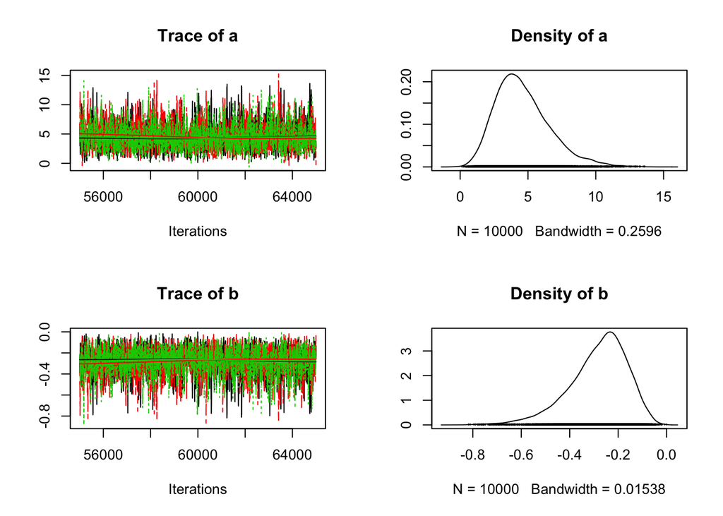

```r
plot(zm)
```

```r
gelman.diag(zm)
```

```
## Potential scale reduction factors:
##
##   Point est. Upper C.I.
## a          1          1
## b          1          1
##
## Multivariate psrf
##
## 1
```

```r
heidel.diag(zm)
```

```
## [[1]]
##
##   Stationarity start     p-value
##   test         iteration
## a passed       1         0.122
## b passed       1         0.130
##
##   Halfwidth Mean  Halfwidth
##   test
## a passed     4.56 0.1907
## b passed    -0.28 0.0115
##
## [[2]]
##
##   Stationarity start     p-value
##   test         iteration
## a passed       1001      0.0603
## b passed       1001      0.0941
##
##   Halfwidth Mean   Halfwidth
##   test
## a passed     4.612 0.1998
## b passed    -0.283 0.0119
##
## [[3]]
##
##   Stationarity start     p-value
##   test         iteration
## a passed       1         0.601
## b passed       1         0.603
##
##   Halfwidth Mean   Halfwidth
##   test
## a passed     4.578 0.1699
## b passed    -0.281 0.0102
```

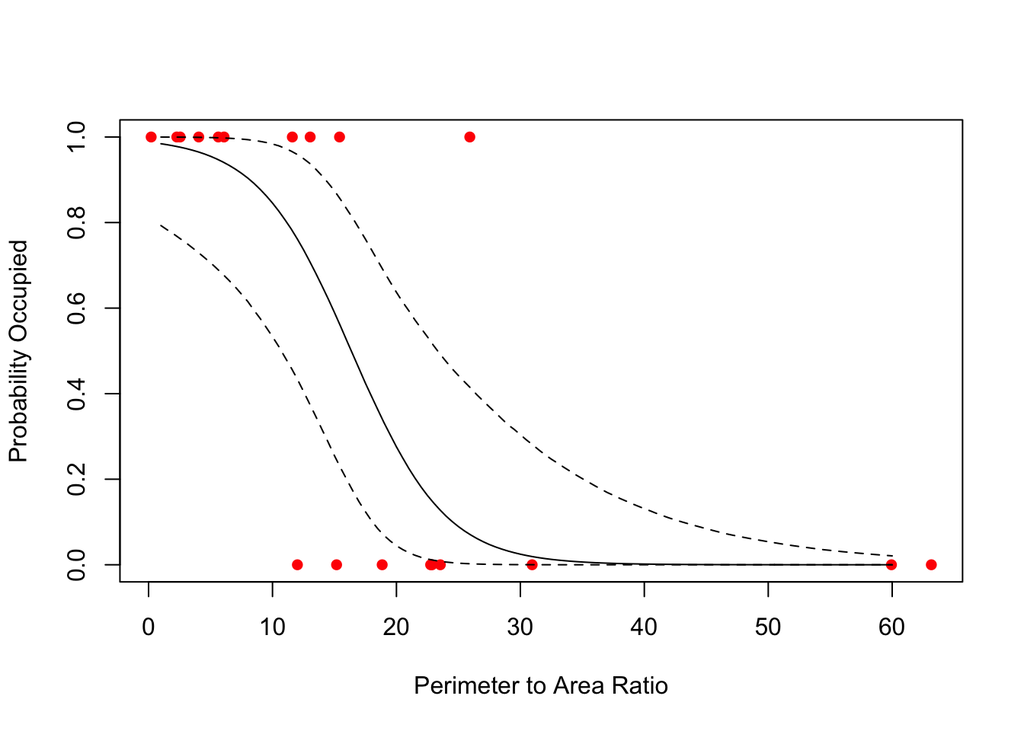

```r
pHat = summary(zj$pHat, quantile, c(.025, .5, .975))$stat
#plot of probability of occupancy
plot(IslandLizards$perimeterAreaRatio, IslandLizards$presence, xlab = "Perimeter to Area Ratio", ylab = "Probability Occupied", pch = 16, col = "red")
lines(seq(1,60,.5), pHat[2,], type = 'l')
lines(seq(1,60,.5), pHat[1,], lty = "dashed")
lines(seq(1,60,.5), pHat[3,], lty = "dashed")
```

```r
##probability of difference in occupancy
p_diff_gt_0=1-ecdf(zj$diff)(0)
print("P(difference > 0")
```

```
## [1] "P(difference > 0"
```

```r
p_diff_gt_0
```

```
## [1] 0.9999667
```

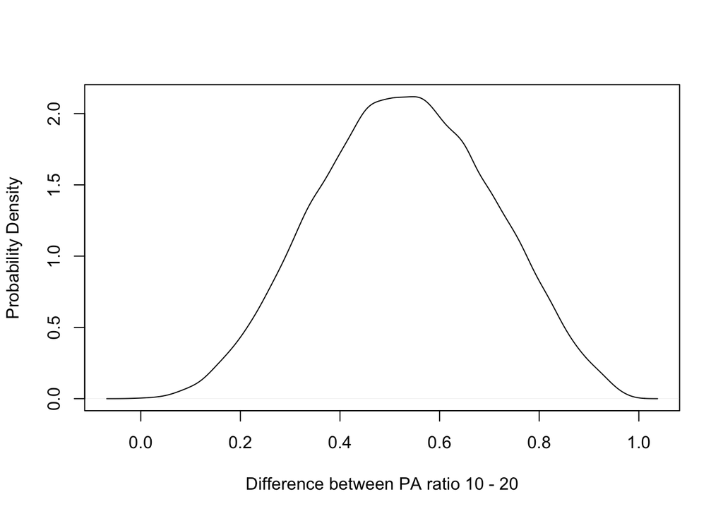

```r
plot(density(zj$diff), main = "", xlab = "Difference between PA ratio 10 - 20", ylab = "Probability Density")
```

#### Advanced Problem

The priors you chose above were vague for the intercept and slope in the logistic regression but they were *not* vague for $p_{i}$. This is generally true for the output of nonlinear functions like the inverse logit (Lunn et al., 2012; Seaman et al., 2012, Northrup and Gerber 2018), so you need to be careful about inference on the output of these non-linear function. For an explanation of this particular case (a logistic regression), see Hobbs and Hooten (2015) section 5.4.1. The solution is to explore the effect of different values for priors on the shape of a the “prior” for quantities that are non-linear functions of model parameters, as demonstrated in the following exercise

8. Write a function that takes an argument for the variance $\sigma^2$. The function should 1) simulate 10000 draws from a normal distribution with mean 0 and variance $\sigma^2$ representing a prior on $a$, remembering, of course, that the argument to `rnorm` is the standard deviation. 2) Plot histograms of the draws for $a$. 3) Plot a histogram of the inverse logit of the random draws, representing a “prior” on $p$ at the mean of $x$ (i.e., where the scaled value of x = 0). Plotting these in side by side panels will facilitate comparison. Use your function to explore the effect of different variances ranging from 1 to 10000 on the priors for $a$ and $p$. Find a value for the variance that produces a flat “prior” on $p$.

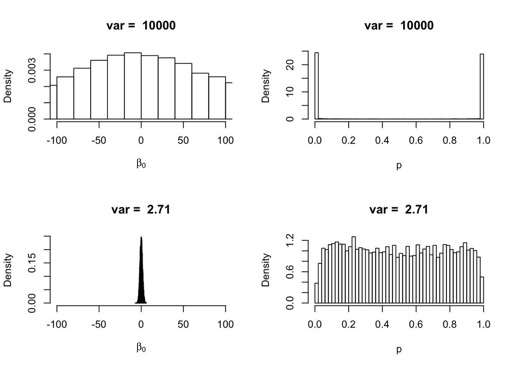

```r
library(boot)
hist_p=function(var, breaks1,breaks2){
  z=rnorm(10000,0,sqrt(var))
  hist(z, xlim=c(-100,100),freq=FALSE, xlab=expression(beta[0]),main=paste("var = ", var),breaks=breaks1)
  hist(inv.logit(z), freq=FALSE, main=paste("var = ", var), breaks=breaks2,xlab="p")
}
par(mfrow=c(2,2))
hist_p(var=10000,50,50)
hist_p(var=2.71,50,50)
```

9. Rerun your analysis using priors on the coefficients that are vague for inference on $p$ based on what you learned in Hobbs and Hooten section 5.4.1 and in exercise 8. (Be careful to convert variance to precision.) Plot the probability of occupancy as a function of perimeter to area ratio using these priors and compare with the plot you obtained in exercise 5, above. You will see that the means of the $p_{i}$ changes and uncertainty about $p_{i}$ increases when you use appropriately vague priors for $p$.

```r
{ # Extra bracket needed only for R markdown files
sink("IslandJAGS.R")
cat("
model{
# priors
  a ~ dnorm(0, .39)
  b ~ dnorm(0, .39)

# likelihood
  for (i in 1:n){
    logit(p[i]) <- a + b*x[i]
    y[i] ~ dbern(p[i])
  }

# derived quantities
  for (j in 1:length(PA)){
    pHat[j] <- ilogit(a + b*PA[j])
  }

} #end of model
",fill = TRUE)
sink()
} # Extra bracket needed only for R markdown files
```

```r
jm = jags.model("IslandJAGS.R", data = data, inits = inits, n.chains = length(inits), n.adapt = n.adapt)
update(jm, n.iter = n.update)
zj2 = jags.samples(jm, variable.names = c("pHat"), n.iter = n.iter, n.thin = 1)
```

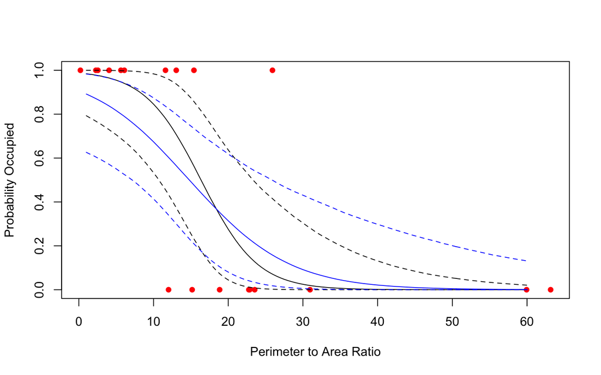

```r
pHat2 = summary(zj2$pHat, quantile, c(.025, .5, .975))$stat

plot(IslandLizards$perimeterAreaRatio, IslandLizards$presence, xlab = "Perimeter to Area Ratio", ylab = "Probability Occupied", pch = 16, col = "red")
lines(seq(1,60,.5), pHat[2,], type = 'l')
lines(seq(1,60,.5), pHat[1,], lty = "dashed")
lines(seq(1,60,.5), pHat[3,], lty = "dashed")
lines(seq(1,60,.5), pHat2[2,], type = 'l', col = "blue")
lines(seq(1,60,.5), pHat2[1,], lty = "dashed", col = "blue")
lines(seq(1,60,.5), pHat2[3,], lty = "dashed", col = "blue")
```

These is conflict between priors that are vague for the parameters and vague for the predictions of the model. If your primary inference is on $p$ then you want to choose values for the priors on $a$ and $b$ that are minimally informative for $p$. The simulation exercise above shows a way to do that. However, what if you need inference on $a$, $b$, and $p$? There are two possibilities. First, get more data so that the influence of the prior becomes small. Second, use informative priors on the coefficients, even weakly informative ones. For example, you *know* that the slope should be negative and you *know* something about the probability of occupancy when islands are large. Centering the slope on a negative value rather than 0 makes sense because we know from many other studies that the probability of occupancy goes down as islands get smaller. Moreover, you could center the prior on the intercept on 3 using the reasoning that large islands are almost certainly occupied (when intercept = 3, p = .95 at PA = 0). Centering the priors on reasonable values (rather than 0) will make the results more precise and far less sensitive to the variance (or precision) chosen for the prior.

Informative priors, even weakly informative ones, are helpful in many ways. We should use them.

#### IV. References

McCarthy, M.A. 2007. *Bayesian Methods for Ecology*. Cambridge University Press, Cambridge, United Kingdom.

Polis, G.A., S.D. Hurd, C.T. Jackson, and F. Sanchez-Pinero, 1998. Multifactor population limitation: Variable spatial and temporal control of spiders on gulf of California islands. Ecology 79:490–502.

Seaman III, J.W., J.W. Seaman Jr., and J.D. Stamey. 2012. Hidden dangers of specifying noninformative priors. The American Statistician 66, 77-84

Hobbs, N. T. and M. B. Hooten. 2015. *Bayesian models: A statistical primer for ecologists*. Princeton University Press, Princeton, New Jersey, USA.

Lunn, D., C. Jackson, N. Best, A. Thomas, and D. Spiegelhalter. 2012. *The BUGS book: A practical introduction to Bayesian analysis*. CRC Press, Boca Raton, Florida, USA.

Northrup, J. M., and B. D. Gerber. 2018. *A comment on priors for Bayesian occupancy models*. PLoS ONE 13.